# Regression Analysis

1. Introduction | Special Lecture for KINS

Boncho Ku, Ph.D. in Statistics

secondmoon@kiom.re.kr

Digital Health Research Division

Korea Institute of Oriental Medicine

2026-09-01

# Introduction

## 회귀분석이란

### 연구 질문

**이 장의 질문**: 회귀분석이란 무엇이며, 어떤 절차로 수행하는가?

**연구 질문**

- 구리 함량과 중성자 조사량이 이 정도일 때 압력용기의 천이온도는 평균적으로 얼마나 올라가는가
- 특정 에너지 대역에서 검출기의 계수 효율은 평균 얼마인가
- 1 Gy를 받은 집단에서 암 위험도는 평균적으로 얼마나 커지는가

세 질문의 공통 형태: **특정 조건이 주어졌을 때의 평균**

- 측정 반복으로는 답이 나오지 않음. 조건이 같아도 결과는 매번 다름
- 회귀분석 = 흩어짐을 인정한 채 조건과 결과의 관계를 하나의 식으로 요약

## 회귀의 의미

### 용어의 기원

회귀(regression, 回歸)는 본래 이전 상태로 되돌아감을 뜻하며, 통계학에서는 **평균(mean)으로의 회귀**을 의미

회귀분석은 변수들 사이의 함수 관계를 자료로부터 탐색

The two roles in a regression model, and the names used for them across fields

| Role | Symbol | 분야별 다른 이름 |
| --- | --- | --- |
| **반응변수** response variable | $y$ | 종속변수(dependent), 출력변수(output), target |
| **설명변수** explanatory variable | $x$ | 독립변수(independent), 입력변수(input), 예측변수(predictor), covariate, regressor, factor, carrier |

**응용 분야**

- **자연·공학** 물리학, 화학, 공학, 기상학
- **생명·의학** 의학, 생물학
- **사회·경제** 경제학, 재무, 법학, 사회학, 심리학
- **교육·기타** 교육학, 스포츠과학, 역사학

## Galton과 회귀의 기원

### 중간부모의 키와 자녀의 키

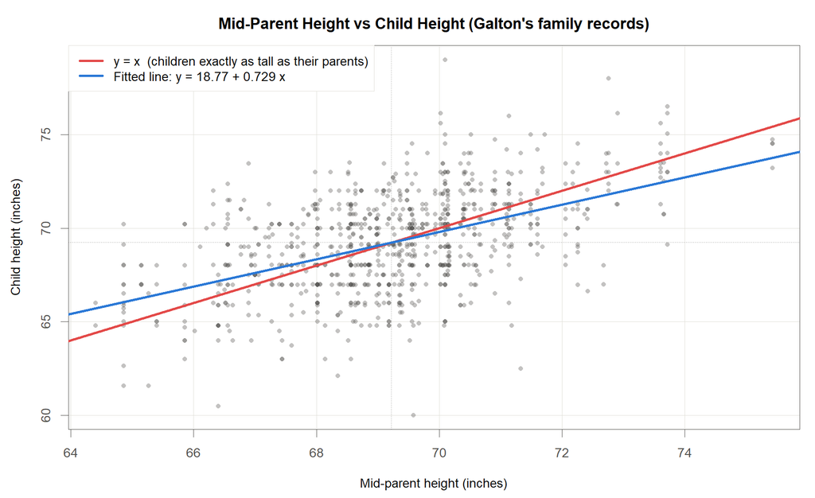

Mid-parent height (explanatory variable) versus child height (response variable), n = 898 children of 197 families, in inches. The red line is y = x, the blue line is the least-squares fit.

**Sir Francis Galton (England, 1822-1911)**

- 회귀(regression)라는 이름을 처음 붙인 사람
- 부모와 자식의 신체 특성이 어떻게 이어지는지를 자료로 따져 본 사람

**자료에 관한 주의**

- 골턴이 직접 모은 **가족 기록**. 197개 가족의 자녀 898명
- 가로축은 **중간부모** = (아버지 + 1.08 × 어머니) ÷ 2
- 빨간 선 $y=x$ 보다 파란 적합선이 **완만함**
- **이 기울기 차이가 회귀의 근거**

Galton, F. (1886). Regression towards mediocrity in hereditary stature. *Journal of the Anthropological Institute of Great Britain and Ireland*, 15, 246-263. / Pearson, K. and Lee, A. (1903). On the laws of inheritance in man. *Biometrika*, 2, 357-462. All female statures (mothers and daughters) are multiplied by 1.08.

## 주변분포와 조건부분포

### 조건에 따른 분포 이동

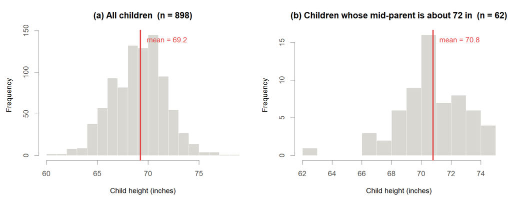

**질문 1. 아무 정보 없이 자식 한 명의 키를 예측한다면**

전체 평균 69.2인치 = 조건을 걸지 않은 **주변분포(marginal distribution)** 의 평균 $E(Y)$

- 기호 $E(\cdot)$ 는 기댓값(expectation), 곧 이론적인 평균

**질문 2. 중간부모의 키가 72인치라는 조건이 있다면**

조건을 만족하는 집단 안의 평균 = **조건부분포(conditional distribution)** 의 평균 $E(Y \mid X = 72)$

- 해당 구간(72 ± 0.75인치, 62명)의 표본평균: 70.8인치
- 회귀직선 $\hat y = 18.8 + 0.729\,x$ 가 $x = 72$ 일 때 71.3인치

질문 1 (marginal)에서 질문 2 (conditional)로의 전환이 회귀분석의 시작

## 국소평균과 회귀직선

### 조건의 세분화

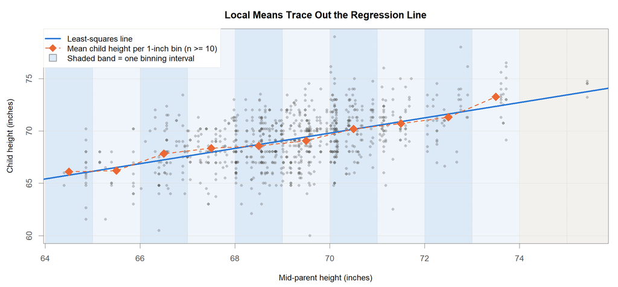

- 중간부모 키를 **1인치 구간**으로 나누어 조건이 여러 개로 확장
- 구간마다 구한 자녀 키의 평균은 **국소평균(local mean)**
- 관측이 10명 미만인 구간(회색 띠)은 평균의 흔들림이 커서 제외

국소평균들이 거의 하나의 직선 위에 놓임 $\rightarrow$ **최소제곱 회귀직선**

## 회귀의 정의

### 정의

**회귀(regression)** 란 설명변수 $X = x$ 가 주어졌을 때 반응변수 $Y$ 의 조건부 기댓값이다.
$$E(Y \mid X = x)$$

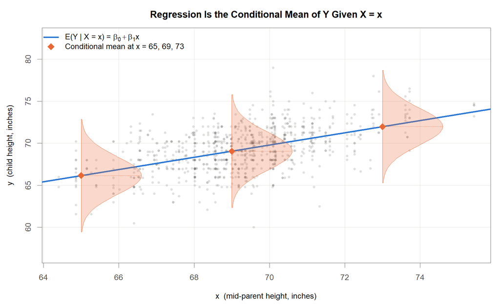

Regression is the conditional mean of Y given X = x. At each x the conditional distribution of Y is centred on the regression line, with the residual standard deviation estimated from the data.

- $Y$: 반응변수
- $X$: 설명변수
- $x$: 설명변수가 갖는 특정한 값 하나
- $E(Y \mid X = x)$: $X = x$ 일때 조건부 평균

**그림 읽는 법**

- 각 $x$ 마다 $Y$ 의 분포가 하나씩 존재
- 그 분포의 중심이 회귀직선 위에 위치
- 회귀직선은 그 중심들을 이은 선

두 변수가 함께 종 모양의 좌우대칭 분포(이변량 정규분포)를 이루면, 이 조건부 기댓값은 정확히 직선

## 회귀모형과 선형회귀모형

### 회귀모형 (regression model)

$$X_1, \; X_2, \; \dots, \; X_p \;\; \longrightarrow \;\; Y, \qquad Y = f(X_1, X_2, \dots, X_p) + \varepsilon$$

- $Y$: 반응변수
- $X_1, \dots, X_p$: $p$ 개의 설명변수
- $\varepsilon$: 확률오차(random error)
- $f$: 설명변수 값이 주어졌을 때 $Y$ 의 조건부 평균, 곧 $f(x) = E(Y \mid X = x)$

### 선형회귀모형 (linear regression model)

$$Y = \beta_0 + \beta_1 X_1 + \beta_2 X_2 + \dots + \beta_p X_p + \varepsilon$$

- $\beta_0, \beta_1, \dots, \beta_p$: 회귀모수(regression parameters), 회귀계수(coefficients)
- $f$ 의 모양을 모르므로 **가장 단순한 형태**인 일차식으로 가정

**Remark**

- 회귀모수 = 자료에서 추정해야 할 **미지의 상수(unknown constants)**
- 자료가 바뀌면 추정값은 바뀌나, 추정 대상인 모수 자체는 고정

## Galton 자료: 모형 적합

### 결과

Least-squares fit of child’s height on mid-parent height, n = 898, from Galton’s family records.

| Term | Estimate | SE | $t$ value | $p$-value |
| --- | --- | --- | --- | --- |
| (Intercept) $\hat\beta_0$ | 18.8 | 2.84 | 6.61 | < 0.001 |
| $x$ (mid-parent height) $\hat\beta_1$ | 0.729 | 0.0410 | 17.8 | < 0.001 |

Analysis of variance for the fitted simple linear model. R-squared = 0.261, residual SD = 2.23 inches.

| Source | Df | Sum Sq | Mean Sq | $F$ value | $p$-value |
| --- | --- | --- | --- | --- | --- |
| $x$ | 1 | 1575 | 1575 | 316 | < 0.001 |
| Residuals | 896 | 4469 | 4.99 | n.a. | n.a. |

### **표의 용어**

- 표준오차(SE): 같은 조사를 되풀이할 때 추정값이 얼마나 흔들리는지를 재는 값
- $t$ 값: 추정값을 그 표준오차로 나눈 값. 절댓값이 클수록 추정값이 0에서 멀다
- $p$ 값: 참값이 0이라고 할 때, 지금 자료에서 나온 것만큼 크거나 더 큰 값이 우연히 나올 확률

**Preliminary Knowledge** 참고

## 회귀분석의 8단계

### 전체 흐름

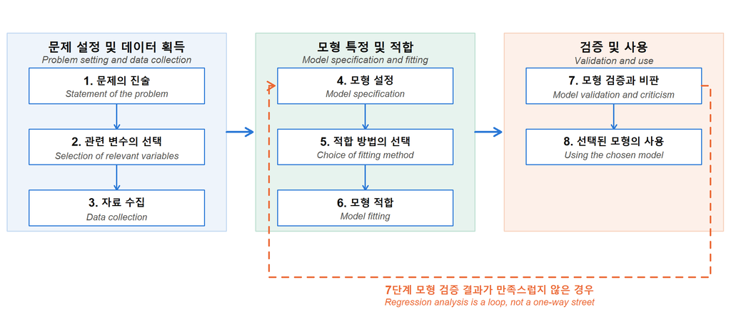

**1단계, 연구 가설과 문제 설정이 가장 중요**

## 1·2단계: 연구 질문과 변수 선택

### 예시: 기온과 판매량

**1단계: 문제의 진술**

- 답해야 할 질문을 한 문장으로 확정: **기온이 오르면 1인당 소비량의 평균이 올라가는가**
- 묻는 대상은 개별 소비량이 아니라 **평균**. 같은 기온의 기간이 여러 번 있어도 소비량은 매번 다름

**2단계: 관련 변수의 선택**

- 기온만으로 충분한가?
- 소비량에 영향을 줄 수 있는 다른 요인이 있을까?

Candidate drivers of ice cream consumption, and the reason each one was collected

| 요인 | 변수 | 유형 | 함께 재는 이유 |
| --- | --- | --- | --- |
| 날씨 | `temp` 평균기온 | 양적 | 질문의 주인공 |
| 가격 | `price` 아이스크림 가격 | 양적 | 비싸지면 덜 사 먹을 것 |
| 소득 | `income` 가족 월수입 | 양적 | 여유가 있으면 더 사 먹을 것 |
| 시기 | `year` 관측 연차 | 질적 | 해가 바뀌며 생긴 전반적 변화 |

## 3단계 자료 수집: 아이스크림 자료

### 30개 기간, 변수 6개

First six of the n = 30 four-week periods

| period | IC | price | income | temp | year |
| --- | --- | --- | --- | --- | --- |
| 1 | 0.386 | 0.270 | 78 | 41 | 0 |
| 2 | 0.374 | 0.282 | 79 | 56 | 0 |
| 3 | 0.393 | 0.277 | 81 | 63 | 0 |
| 4 | 0.425 | 0.280 | 80 | 68 | 0 |
| 5 | 0.406 | 0.272 | 76 | 69 | 0 |
| 6 | 0.344 | 0.262 | 78 | 65 | 0 |

Variables of the ice cream consumption data

| Variable | Symbol | 설명 (단위) | Range | 역할 |
| --- | --- | --- | --- | --- |
| period |  | 기간 번호 | 1 – 30 | 식별자 |
| IC | $y_i$ | 섭취량 (pint) | 0.256 – 0.548 | 반응변수 |
| price | $x_{i1}$ | 가격 (dollar) | 0.260 – 0.292 | 설명변수 |
| income | $x_{i2}$ | 월수입 (dollar) | 76 – 96 | 설명변수 |
| temp | $x_{i3}$ | 평균기온 ($^\circ$F) | 24 – 72 | 설명변수 |
| year |  | 연차 (0, 1, 2) | 0 – 2 | 질적 설명변수 |

- 행 = 관측(4주 단위의 한 기간),
- 열 = 변수. 관측 하나는 네 값의 묶음 $(y_i,\;x_{i1},\;x_{i2},\;x_{i3})$, $i=1,\dots,30$
- $y$ 는 IC, $x_1,x_2,x_3$ 은 각각 price, income, temp 를 가리킴

### **주의 사항**

- `year` 는 계절이 아니라 **관측 연차**(0, 1, 2). 30개 기간이 세 해에 걸쳐 수집되었음을 뜻함.
- 숫자처럼 보이지만 종류를 나누는 변수라 변수 처리 필요 $\rightarrow$ **Dummy Variable**

## 변수의 유형

### 양적 변수와 질적 변수

- **양적 변수**(quantitative): 수치로 측정되는 변수
  - 일반 예: 가격, 소득, 기온, 조사량
  - 아이스크림 자료: `price`, `income`, `temp`
- **질적 변수**(qualitative): 범주로 측정되는 변수
  - 일반 예: 제품 형태(용접재/판재/단조재), 성별(남/여)
  - 아이스크림 자료: `year`
  - 지시변수(indicator) 또는 가변수(dummy variable)로 바꾸어 모형에 넣음

회귀분석에서 **반응변수는 양적**, **설명변수는 양적 또는 질적** 모두 가능.

### 참고: 변수 유형별 모형의 이름

Special names for regression models by the type of the response and the predictors.

| Method | 반응변수 | 설명변수 |
| --- | --- | --- |
| 분산분석 (analysis of variance) | 양적 | 질적 |
| 공분산분석 (analysis of covariance) | 양적 | 양적, 질적 혼합 |
| 로지스틱회귀 (logistic regression) | 질적 (보통 이항) | 양적, 질적 |

## 4단계 모형 설정: 선의 후보

같은 산점도 위에 그을 수 있는 선은 무한함

- **직선** $E(\text{IC}\mid \text{temp}) = \beta_0 + \beta_1\,\text{temp}$: 기온이 1도 오를 때마다 소비량의 평균이 **늘 같은 폭**으로 증가
- **곡선, 이차항** $\beta_0 + \beta_1\,\text{temp} + \beta_2\,\text{temp}^2$: 어느 기온부터 증가가 **완만해지거나 꺾임**
- **곡선, 로그** $\beta_0 + \beta_1 \log(\text{temp})$: 낮은 기온에서 민감하고 높은 기온에서 둔해짐

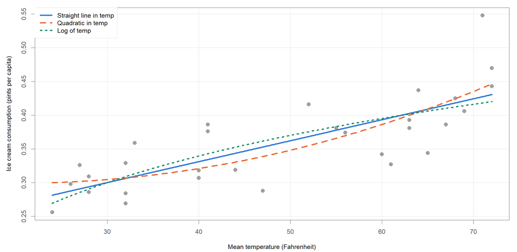

Three candidate shapes fitted to the same 30 observations: a straight line, a quadratic in temperature, and a log transform of temperature.

## 4단계 모형 설정: 모형의 분류

### 분류의 세 기준

4단계는 $E(Y \mid X = x)$ 를 **어떤 형태의 식으로 적을지** 정하는 일. 아이스크림 자료에서 고른 일차식은 여러 선택지 중 하나이며, 모형은 아래 세 기준으로 나뉨

Three criteria for classifying a regression model.

| 무엇을 보는가 | 부르는 이름 | 판정하는 방법 |
| --- | --- | --- |
| 모수가 들어간 방식 | 선형 / 비선형 linear / nonlinear | $\beta_j$ 가 설명항에 **곱해져 더해지면** 선형, 아니면 비선형 |
| 설명항의 개수 | 단순 / 다중 simple / multiple | 모형에 들어간 설명항이 하나면 단순, 둘 이상이면 다중 |
| 반응변수의 개수 | 일변량 / 다변량 univariate / multivariate | 좌변의 $Y$ 가 하나면 일변량, 둘 이상이면 다변량 |

### **주의 사항**

- 선형인지는 **그래프 모양이 아니라 $\beta_j$ 가 들어간 방식**으로 판정. 곡선을 그려도 선형모형일 수 있음
- $\log X$, $X^2$ 처럼 변환한 항은 **각각 별개의 설명항**으로 간주
- 따라서 단순과 다중은 원변수의 개수가 아니라 **모형에 들어간 항의 개수**로 가름

## 모형의 분류: 연습

### 모형 6개 분류

1. $Y = \beta_0 + \beta_1 X_1 + \varepsilon$
2. $Y = \beta_0 + e^{\beta_1 X_1} + \varepsilon$
3. $Y = \beta_0 + \beta_1 X_1 + \beta_2 X_2 + \varepsilon$
4. $Y_1 = \beta_0 + \beta_1 X_1 + \beta_2 X_2 + \varepsilon_1$ 이고 $Y_2 = \gamma_0 + \gamma_1 X_1 + \gamma_2 X_2 + \varepsilon_2$
5. $Y = \beta_0 + \beta_1 \log X_1 + \varepsilon$
6. $Y = \beta_0 + \beta_1 X + \beta_2 X^2 + \varepsilon$

판정 순서: 선형성 → 설명항의 개수 → 반응변수의 개수

## 모형의 분류: 정답과 해설

### 판정 결과

Classification of the six example models.

| 기준 | 해당 모형 |
| --- | --- |
| 선형 (linear) | 1, 3, 4, 5, 6 |
| 비선형 (nonlinear) | 2 |
| 단순 (simple) | 1, 2, 5 |
| 다중 (multiple) | 3, 4, 6 |
| 일변량 (univariate) | 1, 2, 3, 5, 6 |
| 다변량 (multivariate) | 4 |

### **해설**

- 2번은 $\beta_1$ 이 지수 안에 들어가 있어 비선형
- 5번의 $\log X_1$, 6번의 $X^2$ 는 변환된 항이지만 $\beta_j$ 가 곱해져 더해지므로 선형
- 6번은 원변수가 $X$ 하나여도 설명항이 $X$ 와 $X^2$ 로 두 개이므로 다중
- 모형이 선형이면 통상적인 회귀 소프트웨어를 그대로 사용. 1, 3, 4, 5, 6은 모두 같은 절차로 모수를 추정

## 5·6단계 적합 방법과 모형 적합

### 기준과 해법의 구분

**5단계: 무엇을 가장 좋게 만들 것인가 (기준)**

- **최소제곱법**(least squares): 잔차의 **제곱합**을 최소로
  - 가장 보편적이며 이 강의에서 주로 다룰 내용
- **최대가능도법**(maximum likelihood): 지금 자료가 관측될 **가능도**를 최대로 만드는 해
  - 오차가 정규분포를 따른다고 두면 **최소제곱과 같은 추정값**
- **최소절대편차**(least absolute deviations): 잔차의 **절댓값 합**을 최소
  - 튀는 관측에 덜 흔들림

**6단계: 그 기준의 최적점을 어떻게 찾을 것인가 (계산)**

- **닫힌 해(closed solution)**: 정규방정식을 풀어 한 번에
  - $\hat{\boldsymbol\beta} = (\mathbf X^\top\mathbf X)^{-1}\mathbf X^\top\mathbf y$
- **경사하강법**(gradient descent): 기울기를 따라 조금씩 내려가며 **반복**
  - 닫힌 해가 없거나 자료가 아주 클 때
- 두 방법은 **같은 최적점**을 향하는 서로 다른 경로
  - 오차제곱합은 아래로 볼록한 이차함수
  - $\mathbf X^\top\mathbf X$ 의 역행렬이 존재하면 최솟값은 하나뿐
  - 따라서 어느 길로 계산하든 **도달하는 해는 동일**

## 7단계 모형 검증과 비판

### 적합 이후의 점검

**확인해야 할 사항**

- **모형이 자료에 맞는가**: 잔차에 굽은 자국이 남아 있지 않은가. 퍼짐이 한쪽에서만 커지지 않는가
- **한두 관측이 결과를 좌우하지 않는가**: 멀리 떨어진 점, 그 점 하나를 빼면 기울기가 달라지는 점
- **모형에 사용한 변수 모두가 필요한가**: 힘들게 모았더라도 설명에 보탬이 없다면 빼는 편이 나은가

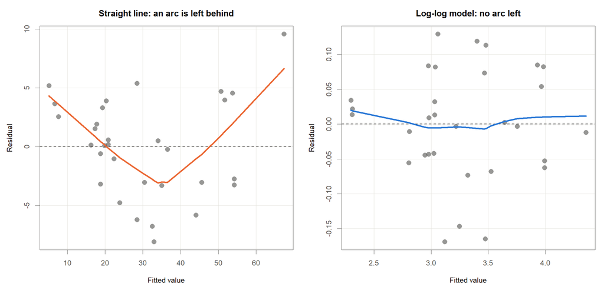

Residual versus fitted value for the same 31 black cherry trees under two models: a straight line in girth (left) and a log-log model in girth and height (right).

## 8단계 선택된 모형의 사용

### 적합값과 예측값의 구분

6단계에서 얻은 계수를 $\hat\beta_0, \hat\beta_1, \dots, \hat\beta_p$ 라 하면, 8단계는 이 식에 설명변수 값을 넣어 답을 얻는 일

$$\hat y_i = \hat\beta_0 + \hat\beta_1 x_{i1} + \dots + \hat\beta_p x_{ip}, \qquad i = 1, \dots, n$$

- $\hat y_i$: $i$ 번째 관측의 적합값
- $x_{ij}$: $i$ 번째 관측의 $j$ 번째 설명변수 값

**언제 적합값이고 언제 예측값인가**

- 적합값(fitted value): **모형을 적합할 때 쓴 그 자료**의 설명변수 값을 다시 넣어 얻은 값 $\hat y_i$
- 예측값(predicted value): **다른 표본, 다른 자료**의 설명변수 값을 넣어 얻은 값 $\hat Y$
- 두 값의 계산식은 동일
- 넣은 설명변수 값이 자료 안의 관측이면 적합값, 자료 밖의 새 값이면 예측값
- 잔차 $e_i = y_i - \hat y_i$ 는 적합값에서만 정의됨

## 원자력 분야의 회귀분석 사례

### 세 사례의 공통 구조

Three regression problems from the nuclear field and the chapter that supplies the tool for each.

| Case | 분야 | 반응변수 $Y$ | 어느 장에서 다루는가 |
| --- | --- | --- | --- |
| 조사취화 예측식 (ASTM E900) | 재료 | 천이온도 변화량 TTS | Dummy Variable |
| 감마선 효율 검교정 | 계측 | 검출 효율 | Weighted Regression |
| 원폭 생존자 선량-반응 (LSS) | 역학 | 고형암 초과상대위험 ERR | Diagnosis & Variable Selection |

세 사례는 재료, 계측, 역학으로 분야가 다르지만 모두 설명변수가 주어졌을 때 반응변수의 조건부 기댓값 $E(Y \mid X = x)$ 를 추정하는 문제임

## 강의의 구성

### 장별 담당 단계

Mapping of the eight steps of regression analysis onto the chapters of this lecture.

| Step | 단계 | 다루는 장 |
| --- | --- | --- |
| 1~3 | 문제의 진술, 관련 변수의 선택, 자료 수집 | Introduction |
| 4 | 모형 설정 | Preliminary Knowledge (행렬 표현), Simple Linear Regression, Multiple Linear Regression, Dummy Variable |
| 5 | 적합 방법의 선택 | Simple Linear Regression (최소제곱), Weighted Regression (가중최소제곱) |
| 6 | 모형 적합 | Simple Linear Regression, Multiple Linear Regression |
| 7 | 모형 검증과 비판 | Diagnosis & Variable Selection |
| 8 | 선택된 모형의 사용 | Simple Linear Regression (구간추정), Multiple Linear Regression (예측) |

## 참고문헌

### 회귀라는 이름의 출발점

- Galton, F. (1877). Typical laws of heredity. *Proceedings of the Royal Institution*, 8, 282-301. (완두콩 실험, 용어는 아직 *reversion*)
- Galton, F. (1885). Presidential address, Section H (Anthropology). British Association for the Advancement of Science. (*regression* 이 처음 등장, 중간부모 기울기 2/3)
- Galton, F. (1886). Regression towards mediocrity in hereditary stature. *Journal of the Anthropological Institute*, 15, 246-263. (성인 자녀 928명, 205가족)
- Pearson, K., & Lee, A. (1903). On the laws of inheritance in man. *Biometrika*, 2, 357-462.
- Gorroochurn, P. (2016). On Galton’s change from “reversion” to “regression”. *The American Statistician*, 70(2), 227-231. doi:10.1080/00031305.2015.1087876
- Stanton, J. M. (2001). Galton, Pearson, and the peas. *Journal of Statistics Education*, 9(3).

### 현장 사례의 출처

- ASTM E900-21e1. *Standard Guide for Predicting Radiation-Induced Transition Temperature Shift in Reactor Vessel Materials*. ASTM International.
- *Metals*, 12(3), 481 (2022). doi:10.3390/met12030481
- *Analytical Chemistry*, 91(7) (2019). doi:10.1021/acs.analchem.9b00119
- INMM Annual Meeting Proceedings. Weighted least squares fitting of gamma spectroscopy efficiency functions.
- Summary of radiation effects on incidence of solid cancers in the Life Span Study of atomic bomb survivors: 1958-2009. *Carcinogenesis* (2025).

### 교과서

- Kutner, M. H., Nachtsheim, C. J., Neter, J., & Li, W. (2005). *Applied Linear Statistical Models*, 5th ed. McGraw-Hill.
- Faraway, J. J. (2015). *Linear Models with R*, 2nd ed. CRC Press.